# COMPSCIX 415.2 Homework 5/Midterm

Ken Vo

March 5, 2019

My Github repository for my assignments can be fournd at this URL: https://github.com/pithunder/compscix-415-2-assignements

# **Table of contents**

## I. R setup code

## II. Loading libraries

## III. Rstudio and R Markdown

## IV. Tidyverse packages

## V. R basics

## VI. Data import/export

## VII. Visualization

## VIII. Data mungling and wrangling

## IX. EDA

### I. R setup code

### II. Loading libraries

```r
library(tidyverse)
library(mdsr)
library(nycflights13)
```

### III. Rstudion and R Markdown

#### Answer: See layout of this document.

### IV. Tidyverse packages

#### Answers to question 1:

#### Plotting is associated with ggplot2 package.

#### Data munging/wrangling is associated with dplyr package.

#### Reshaping (spreading and gathering) data is associated with tidyr package.

#### Importing/exporting data is associated with readr package

#### Answers to question 2:

#### Two functions associated with the ggplot2 package are ggplot() and aes().

#### Two functions associated with the dplyr package are filter() and summarise().

#### Two functions associated with the tidyr package are spred() and unite().

#### Two functions associated with the readr package are read_csv() and write_csv().

### V. R Basics

#### Answers to question 1:

#### Delete the exclamation mark.

#### Answers to question 2:

#### Change the uppercase “C” to lowercase “c”

#### Answers to question 3:

#### The single quote on any one value will return all the value as strings.

### VI. Data import/export:

#### Answers to question 1:

```r
file_path <- "/home/me/Documents/Data Science Certificate Courses/Compscix-415-2/compscix-415-2-assignments/rail_trail.txt"
rail_trail_txt <- read_delim(file=file_path, delim='|')
glimpse(rail_trail_txt)
```

```
## Observations: 90
## Variables: 10
## $ hightemp   <dbl> 83, 73, 74, 95, 44, 69, 66, 66, 80, 79, 78, 65, 41, 5…
## $ lowtemp    <dbl> 50, 49, 52, 61, 52, 54, 39, 38, 55, 45, 55, 48, 49, 3…
## $ avgtemp    <dbl> 66.5, 61.0, 63.0, 78.0, 48.0, 61.5, 52.5, 52.0, 67.5,…
## $ spring     <dbl> 0, 0, 1, 0, 1, 1, 1, 1, 0, 0, 0, 1, 1, 0, 0, 1, 0, 1,…
## $ summer     <dbl> 1, 1, 0, 1, 0, 0, 0, 0, 1, 1, 1, 0, 0, 0, 0, 0, 1, 0,…
## $ fall       <dbl> 0, 0, 0, 0, 0, 0, 0, 0, 0, 0, 0, 0, 0, 1, 1, 0, 0, 0,…
## $ cloudcover <dbl> 7.6, 6.3, 7.5, 2.6, 10.0, 6.6, 2.4, 0.0, 3.8, 4.1, 8.…
## $ precip     <dbl> 0.00, 0.29, 0.32, 0.00, 0.14, 0.02, 0.00, 0.00, 0.00,…
## $ volume     <dbl> 501, 419, 397, 385, 200, 375, 417, 629, 533, 547, 432…
## $ weekday    <dbl> 1, 1, 1, 0, 1, 1, 1, 0, 0, 1, 1, 1, 1, 1, 1, 1, 0, 1,…
```

#### Answers to question 2:

```r
write_delim(rail_trail_txt, path = "/home/me/Documents/Data Science Certificate Courses/Compscix-415-2/compscix-415-2-assignments/rail_trail_delim.csv", delim=',')

file_path_write <- "/home/me/Documents/Data Science Certificate Courses/Compscix-415-2/compscix-415-2-assignments/rail_trail_delim.csv"

rail_trail_delim.csv <- read_csv(file=file_path_write)
glimpse(rail_trail_delim.csv)
```

```
## Observations: 90
## Variables: 10
## $ hightemp   <dbl> 83, 73, 74, 95, 44, 69, 66, 66, 80, 79, 78, 65, 41, 5…
## $ lowtemp    <dbl> 50, 49, 52, 61, 52, 54, 39, 38, 55, 45, 55, 48, 49, 3…
## $ avgtemp    <dbl> 66.5, 61.0, 63.0, 78.0, 48.0, 61.5, 52.5, 52.0, 67.5,…
## $ spring     <dbl> 0, 0, 1, 0, 1, 1, 1, 1, 0, 0, 0, 1, 1, 0, 0, 1, 0, 1,…
## $ summer     <dbl> 1, 1, 0, 1, 0, 0, 0, 0, 1, 1, 1, 0, 0, 0, 0, 0, 1, 0,…
## $ fall       <dbl> 0, 0, 0, 0, 0, 0, 0, 0, 0, 0, 0, 0, 0, 1, 1, 0, 0, 0,…
## $ cloudcover <dbl> 7.6, 6.3, 7.5, 2.6, 10.0, 6.6, 2.4, 0.0, 3.8, 4.1, 8.…
## $ precip     <dbl> 0.00, 0.29, 0.32, 0.00, 0.14, 0.02, 0.00, 0.00, 0.00,…
## $ volume     <dbl> 501, 419, 397, 385, 200, 375, 417, 629, 533, 547, 432…
## $ weekday    <dbl> 1, 1, 1, 0, 1, 1, 1, 0, 0, 1, 1, 1, 1, 1, 1, 1, 0, 1,…
```

### VII. Visualization

#### Answers to question 1:

#### There is no units to the numbers in the circles (e.g. percentage, number of people)

#### The column name for the information in the first column is missiong (should be “Age Range”. “Under 45” could mean under 45 inches.

#### Men and Woman should not be in the same column as “Under 45”.

#### Answers to question 2:

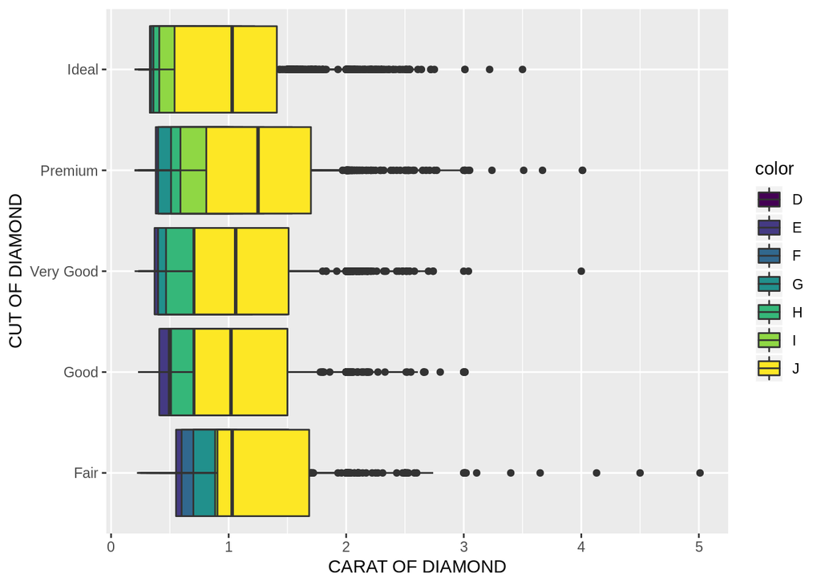

```r
ggplot(data = diamonds)+
  geom_boxplot(mapping = aes(x = cut, y=carat, fill=color), position = position_dodge(width = 0), width=6)+
  coord_flip()+
  xlab("CUT OF DIAMOND")+
  ylab("CARAT OF DIAMOND")
```

#### Answers to question 3:

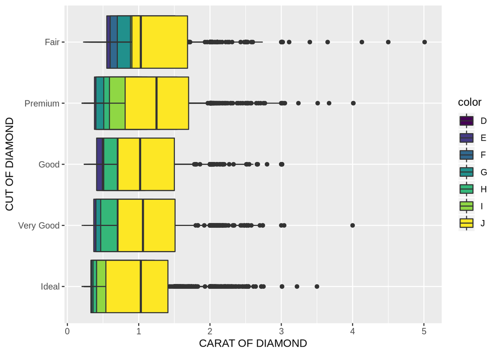

```r
ggplot(data = diamonds)+
  geom_boxplot(mapping = aes(x = reorder(cut, carat, FUN=median), y=carat, fill=color), position = position_dodge(width = 0), width=6)+
  coord_flip()+
  xlab("CUT OF DIAMOND")+
  ylab("CARAT OF DIAMOND")
```

### VIII. Data mungling and wrangling

#### Answers to question 1:

```r
tidy4a <- table4a %>%
  gather(`1999`, `2000`, key = "year", value = "cases")
tidy4b <- table4b %>%
  gather(`1999`, `2000`, key = "year", value = "population")
left_join(tidy4a, tidy4b)
```

```
## # A tibble: 6 x 4
##   country     year   cases population
##   <chr>       <chr>  <int>      <int>
## 1 Afghanistan 1999     745   19987071
## 2 Brazil      1999   37737  172006362
## 3 China       1999  212258 1272915272
## 4 Afghanistan 2000    2666   20595360
## 5 Brazil      2000   80488  174504898
## 6 China       2000  213766 1280428583
```

#### Answers to question 2:

```r
diamonds_more <- select(diamonds, carat, cut, color, clarity, depth, table, price, x, y, z)

mutate(diamonds_more,
       price_per_carat = price / carat)
```

```
## # A tibble: 53,940 x 11
##    carat cut   color clarity depth table price     x     y     z
##    <dbl> <ord> <ord> <ord>   <dbl> <dbl> <int> <dbl> <dbl> <dbl>
##  1 0.23  Ideal E     SI2      61.5    55   326  3.95  3.98  2.43
##  2 0.21  Prem… E     SI1      59.8    61   326  3.89  3.84  2.31
##  3 0.23  Good  E     VS1      56.9    65   327  4.05  4.07  2.31
##  4 0.290 Prem… I     VS2      62.4    58   334  4.2   4.23  2.63
##  5 0.31  Good  J     SI2      63.3    58   335  4.34  4.35  2.75
##  6 0.24  Very… J     VVS2     62.8    57   336  3.94  3.96  2.48
##  7 0.24  Very… I     VVS1     62.3    57   336  3.95  3.98  2.47
##  8 0.26  Very… H     SI1      61.9    55   337  4.07  4.11  2.53
##  9 0.22  Fair  E     VS2      65.1    61   337  3.87  3.78  2.49
## 10 0.23  Very… H     VS1      59.4    61   338  4     4.05  2.39
## # … with 53,930 more rows, and 1 more variable: price_per_carat <dbl>
```

```r
glimpse(diamonds_more)
```

```
## Observations: 53,940
## Variables: 10
## $ carat   <dbl> 0.23, 0.21, 0.23, 0.29, 0.31, 0.24, 0.24, 0.26, 0.22, 0.…
## $ cut     <ord> Ideal, Premium, Good, Premium, Good, Very Good, Very Goo…
## $ color   <ord> E, E, E, I, J, J, I, H, E, H, J, J, F, J, E, E, I, J, J,…
## $ clarity <ord> SI2, SI1, VS1, VS2, SI2, VVS2, VVS1, SI1, VS2, VS1, SI1,…
## $ depth   <dbl> 61.5, 59.8, 56.9, 62.4, 63.3, 62.8, 62.3, 61.9, 65.1, 59…
## $ table   <dbl> 55, 61, 65, 58, 58, 57, 57, 55, 61, 61, 55, 56, 61, 54, …
## $ price   <int> 326, 326, 327, 334, 335, 336, 336, 337, 337, 338, 339, 3…
## $ x       <dbl> 3.95, 3.89, 4.05, 4.20, 4.34, 3.94, 3.95, 4.07, 3.87, 4.…
## $ y       <dbl> 3.98, 3.84, 4.07, 4.23, 4.35, 3.96, 3.98, 4.11, 3.78, 4.…
## $ z       <dbl> 2.43, 2.31, 2.31, 2.63, 2.75, 2.48, 2.47, 2.53, 2.49, 2.…
```

#### Answers to question 3:

```r
#getting the total number of diamonds
count1 <- summarize(diamonds,
                    count=n())

# calculating the proportion for Ideal cut
diamonds_cut_ideal <- filter(diamonds, cut=="Ideal" & price>10000 & carat<1.5)

count_ideal <- summarize(diamonds_cut_ideal,
                        count=n())
proportion_ideal <- count_ideal/count1

proportion_ideal
```

```
##         count
## 1 0.008991472
```

```r
# calculating the proportion for Premium cut
diamonds_cut_premium <- filter(diamonds, cut=="Premium" & price>10000 & carat<1.5)
count_premium <- summarize(diamonds_cut_premium,
                        count=n())
proportion_premium <- count_premium/count1

proportion_premium
```

```
##         count
## 1 0.003207267
```

```r
# calculating the proportion for Very Good cut
diamonds_cut_vg <- filter(diamonds, cut=="Very Good" & price>10000 & carat<1.5)
count_vg <- summarize(diamonds_cut_vg,
                        count=n())
proportion_vg <- count_vg/count1

proportion_vg
```

```
##         count
## 1 0.002873563
```

```r
# calculating the proportion for Good cut
diamonds_cut_g <- filter(diamonds, cut=="Good" & price>10000 & carat<1.5)
count_g <- summarize(diamonds_cut_g,
                        count=n())
proportion_g <- count_g/count1

proportion_g
```

```
##         count
## 1 0.000315165
```

```r
# calculating the proportion for Fair cut
diamonds_cut_f <- filter(diamonds, cut=="Fair" & price>10000 & carat<1.5)
count_f <- summarize(diamonds_cut_f,
                        count=n())
proportion_f <- count_f/count1

proportion_f
```

```
##          count
## 1 7.415647e-05
```

### IX. EDA

#### Answers to question 1:

#### The txhousing data is from 2000-2015.

```r
collection_year <- txhousing %>% select(year)
range(collection_year)
```

```
## [1] 2000 2015
```

#### Answers to question 2:

#### The code below produces 46 distinct cities.

```r
txhousing %>%
  summarise(n_distinct(city))
```

```
## # A tibble: 1 x 1
##   `n_distinct(city)`
##                <int>
## 1                 46
```

#### Answers to question 3:

#### The code below shows Houston is the city with the highest sale in July 2015.

```r
txhousing %>%
  select(city, year, month, sales) %>%
  arrange(desc(sales))
```

```
## # A tibble: 8,602 x 4
##    city     year month sales
##    <chr>   <int> <int> <dbl>
##  1 Houston  2015     7  8945
##  2 Houston  2006     6  8628
##  3 Houston  2013     7  8468
##  4 Houston  2015     6  8449
##  5 Houston  2013     5  8439
##  6 Houston  2014     6  8391
##  7 Houston  2014     7  8391
##  8 Houston  2014     8  8167
##  9 Houston  2013     8  8155
## 10 Houston  2006     5  8040
## # … with 8,592 more rows
```

```r
#  summarise(max(sales))
```

#### Answers to question 4:

#### As the number of sales increases, the number of listings increases.

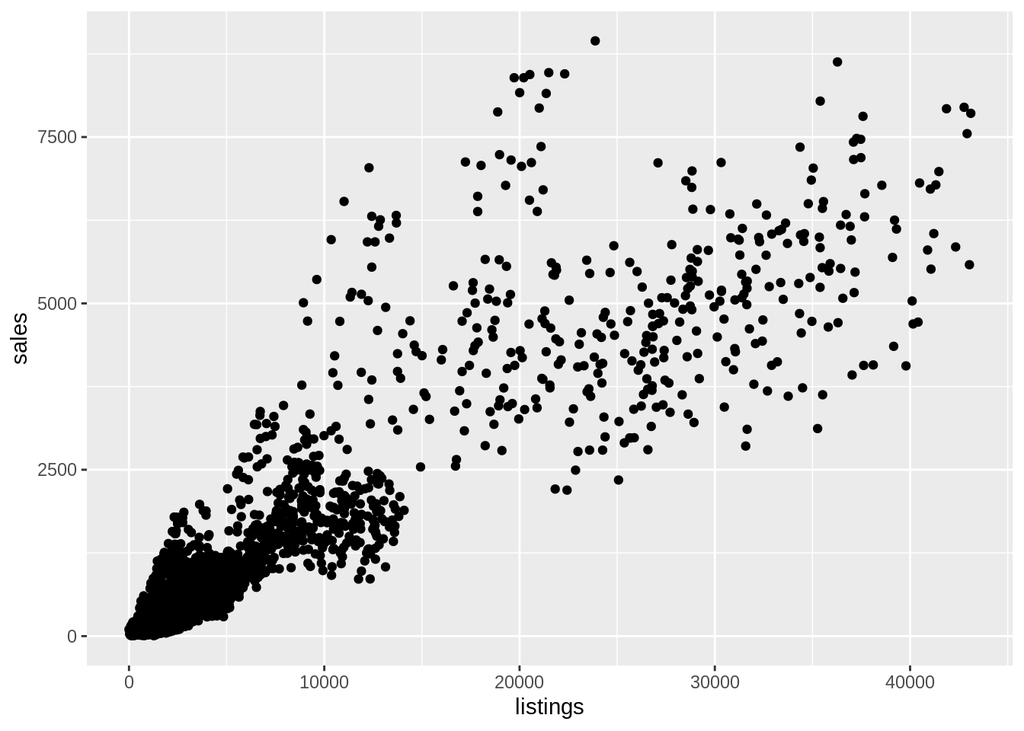

```r
ggplot(txhousing)+
  geom_point(mapping=aes(x=listings, y=sales))
```

#### Answers to question 5:

```r
#creating a table for all sales value equals NA.  This table has two columns: sales, city.  Then, add a column for the proportion.
NA_table_prop <- txhousing %>%
  filter(is.na(sales)) %>%
  select(city, sales) %>%
  group_by(city) %>%
  summarise(n=n()) %>%
  mutate(prop=n/sum(n))

NA_table_prop
```

```
## # A tibble: 20 x 3
##    city                   n    prop
##    <chr>              <int>   <dbl>
##  1 Brazoria County       14 0.0246
##  2 Brownsville            2 0.00352
##  3 Corpus Christi         1 0.00176
##  4 Galveston              1 0.00176
##  5 Harlingen             25 0.0440
##  6 Kerrville            104 0.183
##  7 Killeen-Fort Hood      1 0.00176
##  8 Laredo                36 0.0634
##  9 Longview-Marshall     12 0.0211
## 10 Lubbock                1 0.00176
## 11 McAllen                2 0.00352
## 12 Midland               75 0.132
## 13 Nacogdoches           11 0.0194
## 14 Odessa                72 0.127
## 15 Port Arthur            2 0.00352
## 16 San Marcos            46 0.0810
## 17 South Padre Island   116 0.204
## 18 Temple-Belton         11 0.0194
## 19 Texarkana             17 0.0299
## 20 Waco                  19 0.0335
```

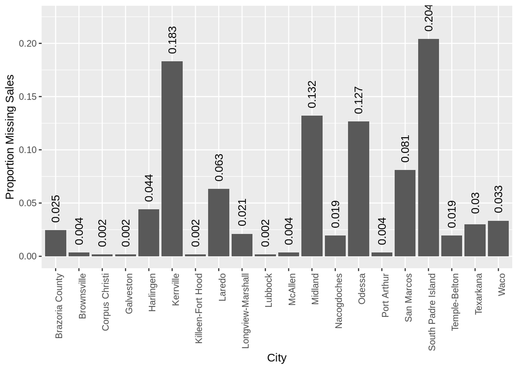

```r
ggplot(NA_table_prop) +
  geom_col(aes(city, y = prop)) +
  geom_text(aes(x = city, y =prop+0.02, label = round(prop, 3)), srt=90)+
  theme(axis.text.x = element_text(angle = 90, hjust = 1))+
  xlab("City")+
  ylab("Proportion Missing Sales")
```

#### Answers to question 6:

#### The median sales price are not the same for the cities while the median sales price for the months are the similar. Cities that stand out are Austin and San Antonio where there is bi-modal distribution.

#### The reason that we want to filter out all cities and months with sales less than 500 is because it would produce manageable data set (less).

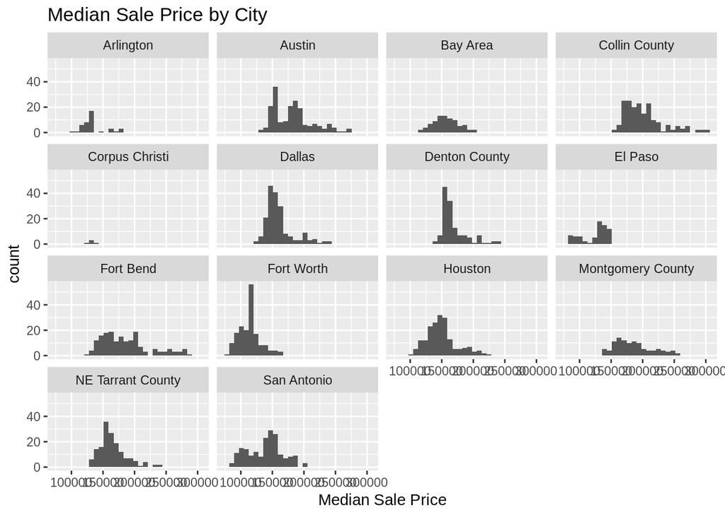

```r
# filtering sales greater than 500 and output columns city, sales and median.
above500_by_city <- txhousing %>%
  filter(sales > 500) %>%
  select(city, median) %>%
  group_by(city)

# filtering sales greater than 500 and output columns month, sales and median
above500_by_month <- txhousing %>%
  filter(sales > 500) %>%
  select(month, median) %>%
  group_by(month)

ggplot(data = above500_by_city, aes(x = median)) +
  geom_histogram() +
  facet_wrap(~city) +
  xlab("Median Sale Price") +
  ggtitle("Median Sale Price by City")
```

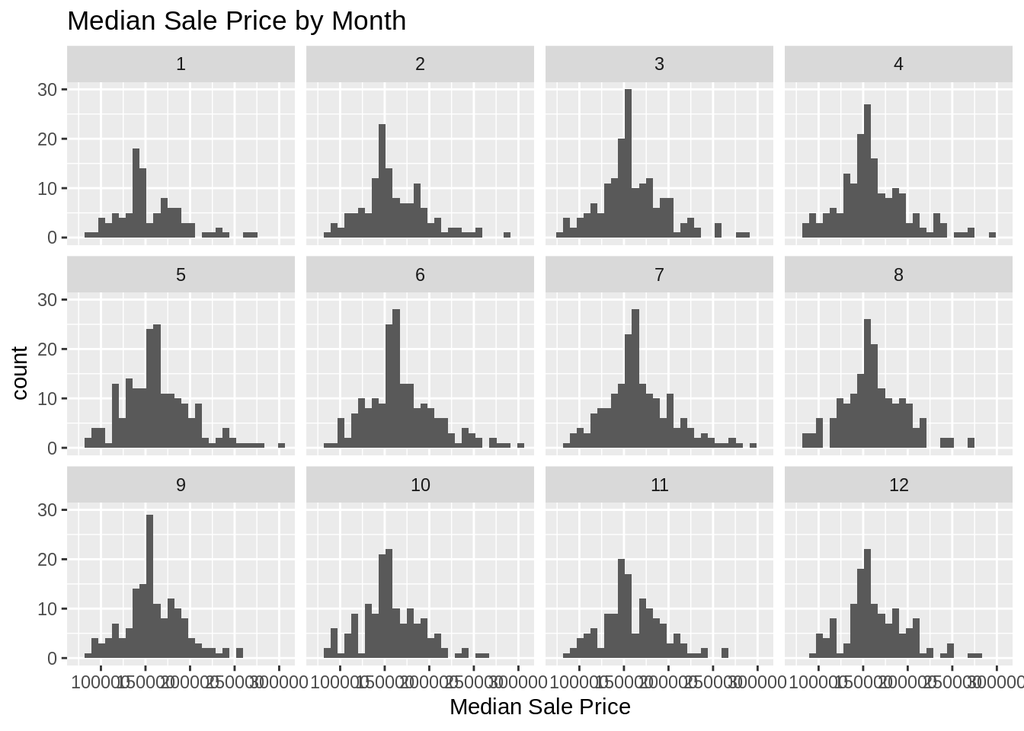

```r
ggplot(data = above500_by_month, aes(x = median)) +
  geom_histogram() +
  facet_wrap(~month) +
  xlab("Median Sale Price") +
  ggtitle("Median Sale Price by Month")
```